# KNN regression model of NYC Green Taxi Trip Records data to determine the tip amount

Sita Patel

2022-08-13

```r
#load packages
library(tidyverse)
```

```r
library(moments)
library(corrplot)
library(lubridate)
library(psych)
```

# CRISP-DM: Data exploration:

The data is explored to identify any patterns and analyze the relationships between the features and the target variable i.e. tip amount. We analysed: 1) the distribution 2) the correlations 3) missing values  
4) outliers

The NYC Green Taxi Trip Records data is loaded into a data frame.

```r
tripdata_df<-read.csv("2018_Green_Taxi_Trip_Data.csv",  header = TRUE, sep= ",", stringsAsFactors = FALSE)
```

• Data distribution:

```r
glimpse(tripdata_df)
```

```
## Rows: 1,048,575
## Columns: 19
## $ VendorID              <int> 2, 2, 2, 2, 2, 2, 2, 2, 2, 2, 2, 2, 2, 2, 2, 1, …
## $ lpep_pickup_datetime  <chr> "1/1/2018 0:18", "1/1/2018 0:30", "1/1/2018 0:07…
## $ lpep_dropoff_datetime <chr> "1/1/2018 0:24", "1/1/2018 0:46", "1/1/2018 0:19…
## $ store_and_fwd_flag    <chr> "N", "N", "N", "N", "N", "N", "N", "N", "N", "N"…
## $ RatecodeID            <int> 1, 1, 1, 1, 1, 1, 1, 1, 1, 1, 1, 1, 1, 1, 1, 1, …
## $ PULocationID          <int> 236, 43, 74, 255, 255, 255, 189, 189, 129, 226, …
## $ DOLocationID          <int> 236, 42, 152, 255, 255, 161, 65, 225, 82, 7, 129…
## $ passenger_count       <int> 5, 5, 1, 1, 1, 1, 5, 5, 1, 1, 2, 2, 1, 1, 2, 1, …
## $ trip_distance         <dbl> 0.70, 3.50, 2.14, 0.03, 0.03, 5.63, 1.71, 3.45, …
## $ fare_amount           <chr> "6", "14.5", "10", "-3", "3", "21", "8.5", "14.5…
## $ extra                 <dbl> 0.5, 0.5, 0.5, -0.5, 0.5, 0.5, 0.5, 0.5, 0.5, 0.…
## $ mta_tax               <dbl> 0.5, 0.5, 0.5, -0.5, 0.5, 0.5, 0.5, 0.5, 0.5, 0.…
## $ tip_amount            <dbl> 0.00, 0.00, 0.00, 0.00, 0.00, 0.00, 0.00, 3.16, …
## $ tolls_amount          <dbl> 0, 0, 0, 0, 0, 0, 0, 0, 0, 0, 0, 0, 0, 0, 0, 0, …
## $ ehail_fee             <lgl> NA, NA, NA, NA, NA, NA, NA, NA, NA, NA, NA, NA, …
## $ improvement_surcharge <dbl> 0.3, 0.3, 0.3, -0.3, 0.3, 0.3, 0.3, 0.3, 0.3, 0.…
## $ total_amount          <chr> "7.3", "15.8", "11.3", "-4.3", "4.3", "22.3", "9…
## $ payment_type          <int> 2, 2, 2, 3, 2, 2, 2, 1, 2, 2, 2, 2, 2, 1, 1, 1, …
## $ trip_type             <int> 1, 1, 1, 1, 1, 1, 1, 1, 1, 1, 1, 1, 1, 1, 1, 1, …
```

```r
summary(tripdata_df)
```

```
##     VendorID     lpep_pickup_datetime lpep_dropoff_datetime store_and_fwd_flag
##  Min.   :1.000   Length:1048575       Length:1048575        Length:1048575
##  1st Qu.:2.000   Class :character     Class :character      Class :character
##  Median :2.000   Mode  :character     Mode  :character      Mode  :character
##  Mean   :1.827
##  3rd Qu.:2.000
##  Max.   :2.000
##
##    RatecodeID      PULocationID  DOLocationID   passenger_count
##  Min.   : 1.000   Min.   :  1   Min.   :  1.0   Min.   :0.000
##  1st Qu.: 1.000   1st Qu.: 49   1st Qu.: 61.0   1st Qu.:1.000
##  Median : 1.000   Median : 82   Median :129.0   Median :1.000
##  Mean   : 1.072   Mean   :110   Mean   :128.5   Mean   :1.359
##  3rd Qu.: 1.000   3rd Qu.:166   3rd Qu.:191.0   3rd Qu.:1.000
##  Max.   :99.000   Max.   :265   Max.   :265.0   Max.   :9.000
##
##  trip_distance     fare_amount            extra            mta_tax
##  Min.   :  0.000   Length:1048575     Min.   :-4.5000   Min.   :-0.5000
##  1st Qu.:  0.990   Class :character   1st Qu.: 0.0000   1st Qu.: 0.5000
##  Median :  1.700   Mode  :character   Median : 0.0000   Median : 0.5000
##  Mean   :  2.662                      Mean   : 0.3445   Mean   : 0.4882
##  3rd Qu.:  3.260                      3rd Qu.: 0.5000   3rd Qu.: 0.5000
##  Max.   :140.620                      Max.   : 4.5000   Max.   : 0.5000
##
##    tip_amount       tolls_amount      ehail_fee      improvement_surcharge
##  Min.   : -2.720   Min.   :  0.0000   Mode:logical   Min.   :-0.3000
##  1st Qu.:  0.000   1st Qu.:  0.0000   NA's:1048575   1st Qu.: 0.3000
##  Median :  0.000   Median :  0.0000                  Median : 0.3000
##  Mean   :  1.037   Mean   :  0.0858                  Mean   : 0.2932
##  3rd Qu.:  1.760   3rd Qu.:  0.0000                  3rd Qu.: 0.3000
##  Max.   :295.000   Max.   :557.5500                  Max.   : 0.3000
##
##  total_amount        payment_type     trip_type
##  Length:1048575     Min.   :1.000   Min.   :1.000
##  Class :character   1st Qu.:1.000   1st Qu.:1.000
##  Mode  :character   Median :1.000   Median :1.000
##                     Mean   :1.471   Mean   :1.018
##                     3rd Qu.:2.000   3rd Qu.:1.000
##                     Max.   :5.000   Max.   :2.000
##                                     NA's   :3
```

```r
str(tripdata_df)
```

```
## 'data.frame':    1048575 obs. of  19 variables:
##  $ VendorID             : int  2 2 2 2 2 2 2 2 2 2 ...
##  $ lpep_pickup_datetime : chr  "1/1/2018 0:18" "1/1/2018 0:30" "1/1/2018 0:07" "1/1/2018 0:32" ...
##  $ lpep_dropoff_datetime: chr  "1/1/2018 0:24" "1/1/2018 0:46" "1/1/2018 0:19" "1/1/2018 0:33" ...
##  $ store_and_fwd_flag   : chr  "N" "N" "N" "N" ...
##  $ RatecodeID           : int  1 1 1 1 1 1 1 1 1 1 ...
##  $ PULocationID         : int  236 43 74 255 255 255 189 189 129 226 ...
##  $ DOLocationID         : int  236 42 152 255 255 161 65 225 82 7 ...
##  $ passenger_count      : int  5 5 1 1 1 1 5 5 1 1 ...
##  $ trip_distance        : num  0.7 3.5 2.14 0.03 0.03 5.63 1.71 3.45 1.61 1.87 ...
##  $ fare_amount          : chr  "6" "14.5" "10" "-3" ...
##  $ extra                : num  0.5 0.5 0.5 -0.5 0.5 0.5 0.5 0.5 0.5 0.5 ...
##  $ mta_tax              : num  0.5 0.5 0.5 -0.5 0.5 0.5 0.5 0.5 0.5 0.5 ...
##  $ tip_amount           : num  0 0 0 0 0 0 0 3.16 0 0 ...
##  $ tolls_amount         : num  0 0 0 0 0 0 0 0 0 0 ...
##  $ ehail_fee            : logi  NA NA NA NA NA NA ...
##  $ improvement_surcharge: num  0.3 0.3 0.3 -0.3 0.3 0.3 0.3 0.3 0.3 0.3 ...
##  $ total_amount         : chr  "7.3" "15.8" "11.3" "-4.3" ...
##  $ payment_type         : int  2 2 2 3 2 2 2 1 2 2 ...
##  $ trip_type            : int  1 1 1 1 1 1 1 1 1 1 ...
```

```r
dim(tripdata_df)
```

```
## [1] 1048575      19
```

```r
#checks each column for the number of NA values. "ehail_fee" column has 1048575 NA values
colSums(is.na(tripdata_df))
```

```
##              VendorID  lpep_pickup_datetime lpep_dropoff_datetime
##                     0                     0                     0
##    store_and_fwd_flag            RatecodeID          PULocationID
##                     0                     0                     0
##          DOLocationID       passenger_count         trip_distance
##                     0                     0                     0
##           fare_amount                 extra               mta_tax
##                     0                     0                     0
##            tip_amount          tolls_amount             ehail_fee
##                     0                     0               1048575
## improvement_surcharge          total_amount          payment_type
##                     0                     0                     0
##             trip_type
##                     3
```

```r
#convert "lpep_pickup_datetime" and "lpep_dropoff_datetime" to POSIXlt data type
tripdata_df$lpep_pickup_datetime<- as.POSIXct(tripdata_df$lpep_pickup_datetime, format="%m/%d/%Y %H:%M")
tripdata_df$lpep_dropoff_datetime<- as.POSIXct(tripdata_df$lpep_dropoff_datetime, format="%m/%d/%Y %H:%M")
#convert remaining columns to numeric data type
tripdata_df$VendorID<-as.numeric(tripdata_df$VendorID)
tripdata_df$RatecodeID<-as.numeric(tripdata_df$RatecodeID)
tripdata_df$PULocationID<-as.numeric(tripdata_df$PULocationID)
tripdata_df$DOLocationID<-as.numeric(tripdata_df$DOLocationID)
tripdata_df$passenger_count<-as.numeric(tripdata_df$passenger_count)
tripdata_df$fare_amount<-as.numeric(tripdata_df$fare_amount)
tripdata_df$total_amount<-as.numeric(tripdata_df$total_amount)
tripdata_df$payment_type<-as.numeric(tripdata_df$payment_type)
tripdata_df$trip_type<-as.numeric(tripdata_df$trip_type)
tripdata_df$store_and_fwd_flag<-as.numeric(as.factor(tripdata_df$store_and_fwd_flag))
```

```r
str(tripdata_df)
```

```
## 'data.frame':    1048575 obs. of  19 variables:
##  $ VendorID             : num  2 2 2 2 2 2 2 2 2 2 ...
##  $ lpep_pickup_datetime : POSIXct, format: "2018-01-01 00:18:00" "2018-01-01 00:30:00" ...
##  $ lpep_dropoff_datetime: POSIXct, format: "2018-01-01 00:24:00" "2018-01-01 00:46:00" ...
##  $ store_and_fwd_flag   : num  1 1 1 1 1 1 1 1 1 1 ...
##  $ RatecodeID           : num  1 1 1 1 1 1 1 1 1 1 ...
##  $ PULocationID         : num  236 43 74 255 255 255 189 189 129 226 ...
##  $ DOLocationID         : num  236 42 152 255 255 161 65 225 82 7 ...
##  $ passenger_count      : num  5 5 1 1 1 1 5 5 1 1 ...
##  $ trip_distance        : num  0.7 3.5 2.14 0.03 0.03 5.63 1.71 3.45 1.61 1.87 ...
##  $ fare_amount          : num  6 14.5 10 -3 3 21 8.5 14.5 10 7.5 ...
##  $ extra                : num  0.5 0.5 0.5 -0.5 0.5 0.5 0.5 0.5 0.5 0.5 ...
##  $ mta_tax              : num  0.5 0.5 0.5 -0.5 0.5 0.5 0.5 0.5 0.5 0.5 ...
##  $ tip_amount           : num  0 0 0 0 0 0 0 3.16 0 0 ...
##  $ tolls_amount         : num  0 0 0 0 0 0 0 0 0 0 ...
##  $ ehail_fee            : logi  NA NA NA NA NA NA ...
##  $ improvement_surcharge: num  0.3 0.3 0.3 -0.3 0.3 0.3 0.3 0.3 0.3 0.3 ...
##  $ total_amount         : num  7.3 15.8 11.3 -4.3 4.3 ...
##  $ payment_type         : num  2 2 2 3 2 2 2 1 2 2 ...
##  $ trip_type            : num  1 1 1 1 1 1 1 1 1 1 ...
```

```r
summary(tripdata_df)
```

```
##     VendorID     lpep_pickup_datetime          lpep_dropoff_datetime
##  Min.   :1.000   Min.   :2009-01-01 00:02:00   Min.   :2009-01-01 11:16:00
##  1st Qu.:2.000   1st Qu.:2018-01-12 04:21:30   1st Qu.:2018-01-12 05:11:00
##  Median :2.000   Median :2018-01-21 18:47:00   Median :2018-01-21 19:07:00
##  Mean   :1.827   Mean   :2018-01-21 17:48:24   Mean   :2018-01-21 18:08:24
##  3rd Qu.:2.000   3rd Qu.:2018-01-31 18:58:00   3rd Qu.:2018-01-31 19:14:00
##  Max.   :2.000   Max.   :2018-04-05 04:11:00   Max.   :2018-04-05 04:25:00
##
##  store_and_fwd_flag   RatecodeID      PULocationID  DOLocationID
##  Min.   :1.000      Min.   : 1.000   Min.   :  1   Min.   :  1.0
##  1st Qu.:1.000      1st Qu.: 1.000   1st Qu.: 49   1st Qu.: 61.0
##  Median :1.000      Median : 1.000   Median : 82   Median :129.0
##  Mean   :1.002      Mean   : 1.072   Mean   :110   Mean   :128.5
##  3rd Qu.:1.000      3rd Qu.: 1.000   3rd Qu.:166   3rd Qu.:191.0
##  Max.   :2.000      Max.   :99.000   Max.   :265   Max.   :265.0
##
##  passenger_count trip_distance      fare_amount          extra
##  Min.   :0.000   Min.   :  0.000   Min.   :-183.00   Min.   :-4.5000
##  1st Qu.:1.000   1st Qu.:  0.990   1st Qu.:   6.00   1st Qu.: 0.0000
##  Median :1.000   Median :  1.700   Median :   9.00   Median : 0.0000
##  Mean   :1.359   Mean   :  2.662   Mean   :  11.72   Mean   : 0.3445
##  3rd Qu.:1.000   3rd Qu.:  3.260   3rd Qu.:  14.00   3rd Qu.: 0.5000
##  Max.   :9.000   Max.   :140.620   Max.   : 999.99   Max.   : 4.5000
##                                    NA's   :5
##     mta_tax          tip_amount       tolls_amount      ehail_fee
##  Min.   :-0.5000   Min.   : -2.720   Min.   :  0.0000   Mode:logical
##  1st Qu.: 0.5000   1st Qu.:  0.000   1st Qu.:  0.0000   NA's:1048575
##  Median : 0.5000   Median :  0.000   Median :  0.0000
##  Mean   : 0.4882   Mean   :  1.037   Mean   :  0.0858
##  3rd Qu.: 0.5000   3rd Qu.:  1.760   3rd Qu.:  0.0000
##  Max.   : 0.5000   Max.   :295.000   Max.   :557.5500
##
##  improvement_surcharge  total_amount      payment_type     trip_type
##  Min.   :-0.3000       Min.   :-183.00   Min.   :1.000   Min.   :1.000
##  1st Qu.: 0.3000       1st Qu.:   7.80   1st Qu.:1.000   1st Qu.:1.000
##  Median : 0.3000       Median :  10.80   Median :1.000   Median :1.000
##  Mean   : 0.2932       Mean   :  13.99   Mean   :1.471   Mean   :1.018
##  3rd Qu.: 0.3000       3rd Qu.:  16.80   3rd Qu.:2.000   3rd Qu.:1.000
##  Max.   : 0.3000       Max.   : 999.99   Max.   :5.000   Max.   :2.000
##                        NA's   :5                         NA's   :3
```

```r
#"RatecodeID" should only be between 1 and 6, but the max is 99.
#"fare_amount", "extra", "mta_tax", "tip_amount", "improvement_surcharge", and "total_amount" all have negative values which could be error or refunds and should be excluded.
#remove "ehail_fee" column since it is entirely made up of NAs. And remove NAs from "trip_type", "fare_amount", "total_amount".
#And filtering out data in the year of 2018 only.
tripdata<-tripdata_df%>%
  select(-ehail_fee) %>%
  drop_na(trip_type, fare_amount, total_amount) %>%
  filter(RatecodeID<7, fare_amount>=0, extra>=0,mta_tax>=0, tip_amount>=0,improvement_surcharge>=0,
        total_amount>=0) %>%
  filter(year(lpep_pickup_datetime)==2018&year(lpep_pickup_datetime)==2018)

summary(tripdata)
```

```
##     VendorID     lpep_pickup_datetime          lpep_dropoff_datetime
##  Min.   :1.000   Min.   :2018-01-01 00:00:00   Min.   :2018-01-01 00:00:00
##  1st Qu.:2.000   1st Qu.:2018-01-12 04:45:00   1st Qu.:2018-01-12 05:38:15
##  Median :2.000   Median :2018-01-21 18:49:00   Median :2018-01-21 19:09:00
##  Mean   :1.826   Mean   :2018-01-21 19:01:48   Mean   :2018-01-21 19:21:48
##  3rd Qu.:2.000   3rd Qu.:2018-01-31 18:58:00   3rd Qu.:2018-01-31 19:14:00
##  Max.   :2.000   Max.   :2018-04-05 04:11:00   Max.   :2018-04-05 04:25:00
##  store_and_fwd_flag   RatecodeID     PULocationID    DOLocationID
##  Min.   :1.000      Min.   :1.000   Min.   :  1.0   Min.   :  1.0
##  1st Qu.:1.000      1st Qu.:1.000   1st Qu.: 49.0   1st Qu.: 61.0
##  Median :1.000      Median :1.000   Median : 82.0   Median :129.0
##  Mean   :1.002      Mean   :1.072   Mean   :109.9   Mean   :128.5
##  3rd Qu.:1.000      3rd Qu.:1.000   3rd Qu.:166.0   3rd Qu.:192.0
##  Max.   :2.000      Max.   :6.000   Max.   :265.0   Max.   :265.0
##  passenger_count trip_distance      fare_amount          extra
##  Min.   :0.000   Min.   :  0.000   Min.   :   0.00   Min.   :0.0000
##  1st Qu.:1.000   1st Qu.:  0.990   1st Qu.:   6.00   1st Qu.:0.0000
##  Median :1.000   Median :  1.700   Median :   9.00   Median :0.0000
##  Mean   :1.359   Mean   :  2.667   Mean   :  11.76   Mean   :0.3462
##  3rd Qu.:1.000   3rd Qu.:  3.270   3rd Qu.:  14.00   3rd Qu.:0.5000
##  Max.   :9.000   Max.   :140.620   Max.   : 999.99   Max.   :4.5000
##     mta_tax         tip_amount      tolls_amount     improvement_surcharge
##  Min.   :0.0000   Min.   :  0.00   Min.   :  0.000   Min.   :0.0000
##  1st Qu.:0.5000   1st Qu.:  0.00   1st Qu.:  0.000   1st Qu.:0.3000
##  Median :0.5000   Median :  0.00   Median :  0.000   Median :0.3000
##  Mean   :0.4906   Mean   :  1.04   Mean   :  0.086   Mean   :0.2946
##  3rd Qu.:0.5000   3rd Qu.:  1.76   3rd Qu.:  0.000   3rd Qu.:0.3000
##  Max.   :0.5000   Max.   :295.00   Max.   :557.550   Max.   :0.3000
##   total_amount      payment_type     trip_type
##  Min.   :   0.00   Min.   :1.000   Min.   :1.000
##  1st Qu.:   7.80   1st Qu.:1.000   1st Qu.:1.000
##  Median :  10.80   Median :1.000   Median :1.000
##  Mean   :  14.04   Mean   :1.466   Mean   :1.018
##  3rd Qu.:  16.80   3rd Qu.:2.000   3rd Qu.:1.000
##  Max.   : 999.99   Max.   :5.000   Max.   :2.000
```

```r
#check if all NAs are removed
colSums(is.na(tripdata))
```

```
##              VendorID  lpep_pickup_datetime lpep_dropoff_datetime
##                     0                     0                     0
##    store_and_fwd_flag            RatecodeID          PULocationID
##                     0                     0                     0
##          DOLocationID       passenger_count         trip_distance
##                     0                     0                     0
##           fare_amount                 extra               mta_tax
##                     0                     0                     0
##            tip_amount          tolls_amount improvement_surcharge
##                     0                     0                     0
##          total_amount          payment_type             trip_type
##                     0                     0                     0
```

```r
#trip_distance distribution
skewness(tripdata$trip_distance)
```

```
## [1] 3.482477
```

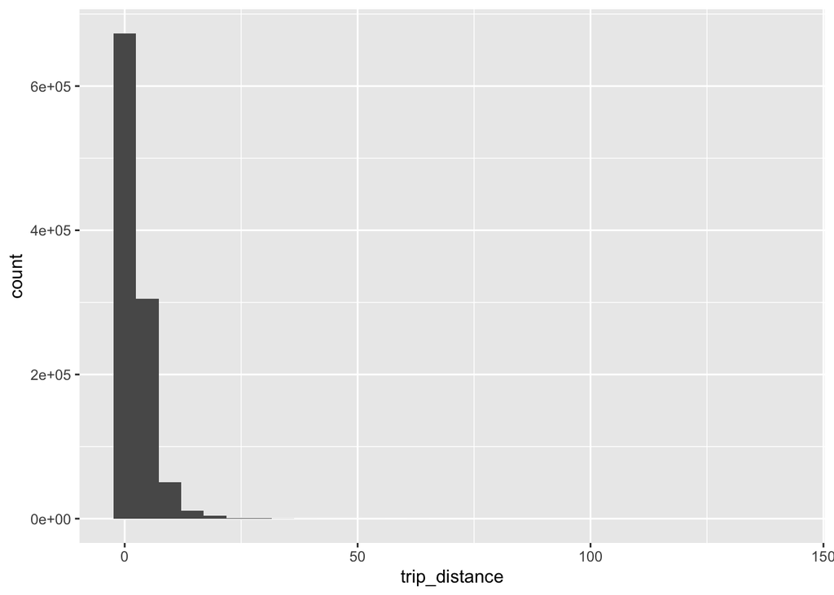

```r
ggplot(tripdata, aes(x=trip_distance))+geom_histogram()
```

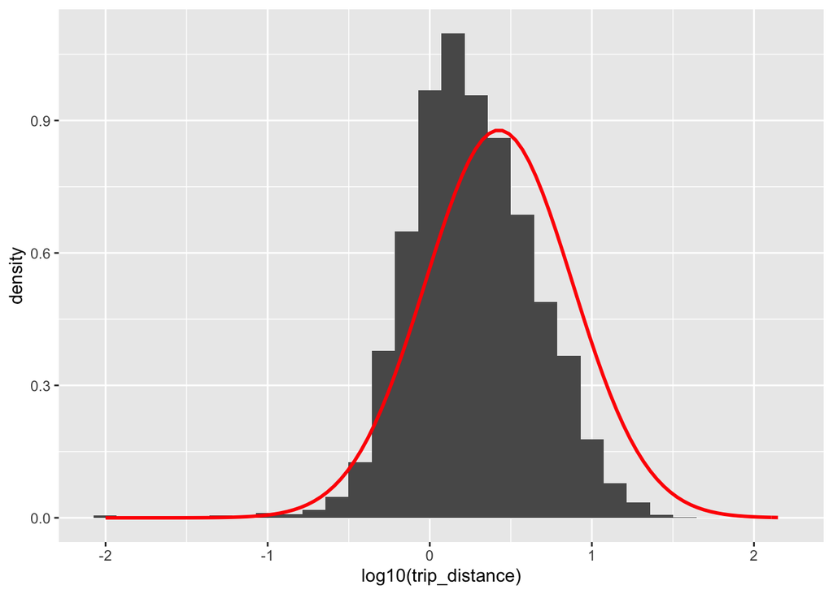

```r
ggplot(tripdata, aes(x=log10(trip_distance)))+geom_histogram(aes(y=..density..))+
  stat_function(fun=dnorm,args = list(mean=log10(mean(tripdata$trip_distance)),
                                      sd=log10(sd(tripdata$trip_distance))),color="red", size=1)
```

- Trip_distance is skewed to the right by 3.482477

```r
skewness(tripdata$fare_amount)
```

```
## [1] 6.194969
```

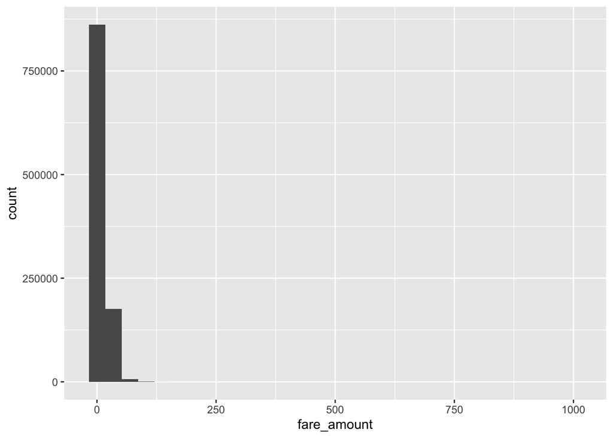

```r
ggplot(tripdata, aes(x=fare_amount))+geom_histogram()
```

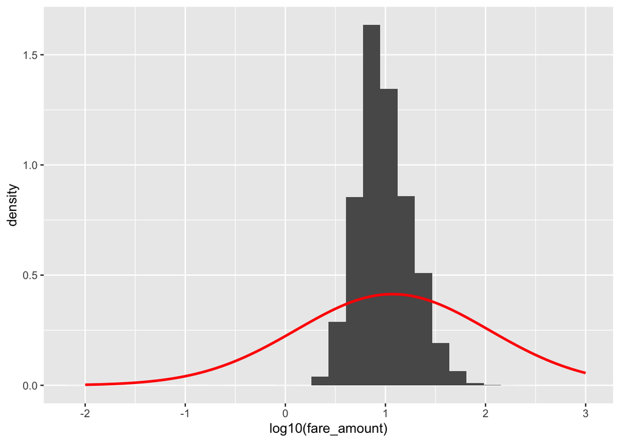

```r
ggplot(tripdata,aes(x=log10(fare_amount)))+geom_histogram(aes(y=..density..))+
  stat_function(fun=dnorm,args=list(mean=log10(mean(tripdata$fare_amount)),
                                    sd=log10(sd(tripdata$fare_amount))),colour='red',size=1)
```

- Fare_amount is skewed to the right by 6.194969

```r
skewness(tripdata$total_amount)
```

```
## [1] 5.558879
```

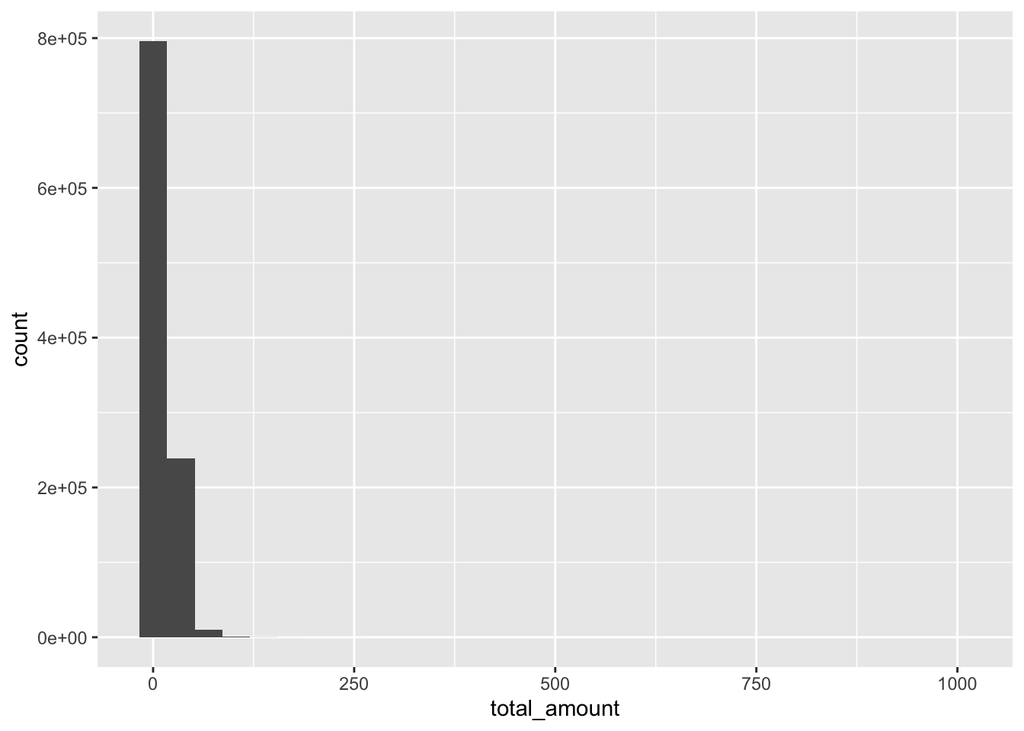

```r
ggplot(tripdata, aes(x=total_amount))+geom_histogram()
```

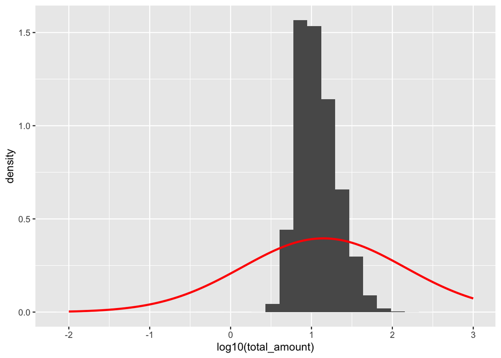

```r
ggplot(tripdata,aes(x=log10(total_amount)))+geom_histogram(aes(y=..density..))+
  stat_function(fun=dnorm,args=list(mean=log10(mean(tripdata$total_amount)),
                                    sd=log10(sd(tripdata$total_amount))),colour='red',size=1)
```

- Total_amount is skewed to the right by 5.558879.

```r
skewness(tripdata$tip_amount)
```

```
## [1] 13.48808
```

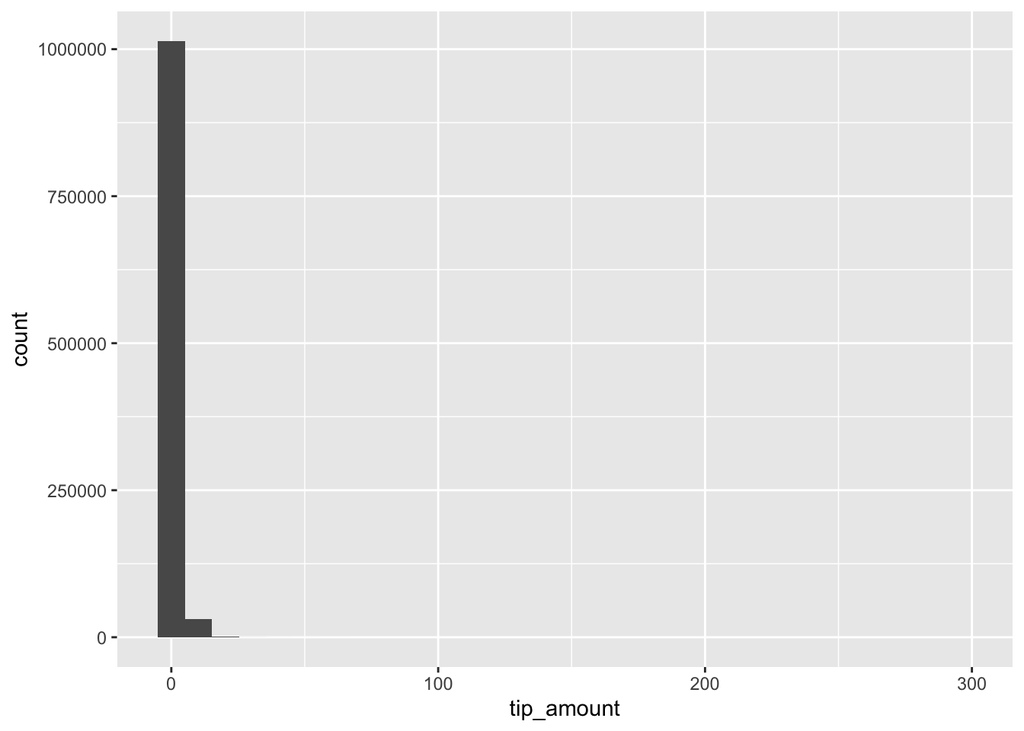

```r
ggplot(tripdata, aes(x=tip_amount))+geom_histogram()
```

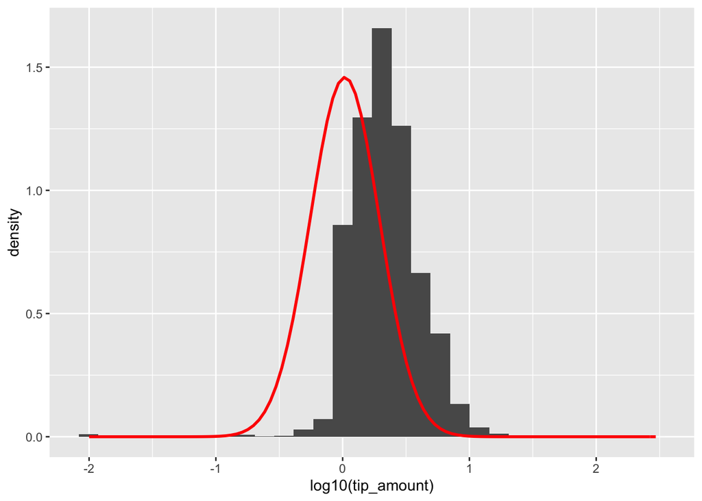

```r
ggplot(tripdata, aes(x=log10(tip_amount)))+geom_histogram(aes(y=..density..))+stat_function(fun=dnorm,args = list(mean=log10(mean(tripdata$tip_amount)), sd=log10(sd(tripdata$tip_amount))),color="red", size=1)
```

- Tip_amount is skewed to the right by 13.48808.

• Correlation:

```r
#correlations between independent variables
cor(tripdata[,-c(2,3,13)])
```

```
##                           VendorID store_and_fwd_flag    RatecodeID
## VendorID               1.000000000      -8.820860e-02 -0.0170153503
## store_and_fwd_flag    -0.088208602       1.000000e+00  0.0004781427
## RatecodeID            -0.017015350       4.781427e-04  1.0000000000
## PULocationID           0.008745841      -1.538763e-04  0.0581975794
## DOLocationID          -0.000993696       2.401576e-03  0.0238104416
## passenger_count        0.091740276      -7.727101e-03 -0.0086415498
## trip_distance          0.025781411      -2.677949e-03  0.0496853703
## fare_amount            0.035731648      -2.907870e-03  0.1111668651
## extra                 -0.003780906       7.192486e-03 -0.1101743228
## mta_tax                0.012196735       3.492753e-04 -0.9361702401
## tolls_amount           0.002226003       3.863441e-04  0.0305272312
## improvement_surcharge  0.011138818      -7.482614e-05 -0.9244219665
## total_amount           0.028103567      -2.628860e-03  0.0884327384
## payment_type          -0.058697042       1.103186e-02  0.0425184547
## trip_type             -0.011091721      -1.277966e-03  0.9364785170
##                        PULocationID DOLocationID passenger_count trip_distance
## VendorID               0.0087458413 -0.000993696     0.091740276   0.025781411
## store_and_fwd_flag    -0.0001538763  0.002401576    -0.007727101  -0.002677949
## RatecodeID             0.0581975794  0.023810442    -0.008641550   0.049685370
## PULocationID           1.0000000000  0.162034598     0.016240463   0.053653388
## DOLocationID           0.1620345980  1.000000000     0.006565940   0.081698706
## passenger_count        0.0162404631  0.006565940     1.000000000   0.002300595
## trip_distance          0.0536533877  0.081698706     0.002300595   1.000000000
## fare_amount            0.0457575253  0.075154867     0.002845670   0.901194944
## extra                  0.0171998909 -0.009587920     0.010460510  -0.051830731
## mta_tax               -0.0583745867 -0.020347020     0.011059739  -0.027660704
## tolls_amount           0.0192912584  0.015302611     0.007861366   0.240720753
## improvement_surcharge -0.0582169088 -0.022093929     0.010682451  -0.019806922
## total_amount           0.0474743329  0.082549682     0.004712869   0.893478524
## payment_type          -0.0082787749 -0.037833740    -0.000264192  -0.137162755
## trip_type              0.0560627243  0.019739776    -0.010378080   0.021524492
##                       fare_amount        extra       mta_tax  tolls_amount
## VendorID               0.03573165 -0.003780906  0.0121967348  0.0022260029
## store_and_fwd_flag    -0.00290787  0.007192486  0.0003492753  0.0003863441
## RatecodeID             0.11116687 -0.110174323 -0.9361702401  0.0305272312
## PULocationID           0.04575753  0.017199891 -0.0583745867  0.0192912584
## DOLocationID           0.07515487 -0.009587920 -0.0203470199  0.0153026112
## passenger_count        0.00284567  0.010460510  0.0110597387  0.0078613659
## trip_distance          0.90119494 -0.051830731 -0.0276607043  0.2407207527
```

[output cut: 25 more lines]

```
## VendorID              -0.011091721
## store_and_fwd_flag    -0.001277966
## RatecodeID             0.936478517
## PULocationID           0.056062724
## DOLocationID           0.019739776
## passenger_count       -0.010378080
## trip_distance          0.021524492
## fare_amount            0.074465020
## extra                 -0.111239564
## mta_tax               -0.967886524
## tolls_amount           0.006216394
## improvement_surcharge -0.979562313
## total_amount           0.049286086
## payment_type           0.046425967
## trip_type              1.000000000
```

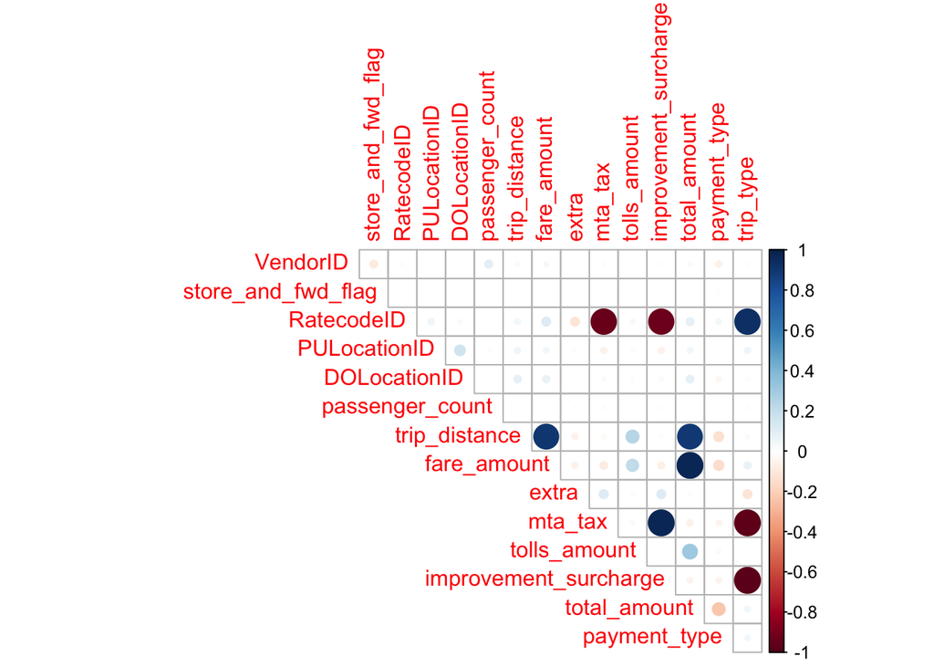

```r
corrplot(cor(tripdata[,-c(2,3,13)]),diag=F,type = "upper")
```

- Strong correlations between independent variables:
  - “trip_distance” and “fare_amount” has a correlation of 0.90.
  - “RatecodeID” and “mta_tax” has a correlation of -0.94.
  - “RatecodeID” and “improvement_surcharge” has a correlation of -0.92.
  - “mta_tax” and “improvement_surcharge” has a correlation of 0.98.
  - “fare_amount” and “total_amount” has a correlation of 0.977.
  - “trip_distance” and “total_amount” has a correlation of 0.894.
  - “RatecodeID” and “trip_type” has a correlation of 0.936.
  - “mta_tax” and “trip_type” has a correlation of -0.968.
  - “improvement_surcharge” and “trip_type” has a correlation of -0.9796.

```r
#correlations between dependent variable and independent variables.
cor(tripdata$tip_amount,tripdata[,-c(2,3)] )
```

```
##         VendorID store_and_fwd_flag   RatecodeID PULocationID DOLocationID
## [1,] -0.03027216       -0.001161419 -0.002396531   0.02198488   0.07459921
##      passenger_count trip_distance fare_amount      extra    mta_tax tip_amount
## [1,]     0.003067768     0.3145847   0.3014266 0.02703558 0.01444162          1
##      tolls_amount improvement_surcharge total_amount payment_type   trip_type
## [1,]    0.1388663            0.02199263    0.4733899   -0.5029547 -0.01989157
```

- By looking at the correlations between “tip_amount” and the rest of the variables: “trip_distance”, “fare_amount”, “tolls_amount”, total_amount”, “payment_type” and “DOLocationID” seems to have stronger correlation with “tip_amount”.

• Outliers:

```r
#outliers
zscore<-as.data.frame(sapply(tripdata[,9:18],function(z) (abs(z-mean(z))/sd(z))))

out<-function(zscore){
  result<-which(zscore>3)
  length(result)
}

apply(zscore,2,out)
```

```
##         trip_distance           fare_amount                 extra
##                 20943                 19068                   291
##               mta_tax            tip_amount          tolls_amount
##                 19619                 14444                 13848
## improvement_surcharge          total_amount          payment_type
##                 18749                 18899                  1490
##             trip_type
##                 18455
```

- The outliers are selected if their z scores are greater then 3 which means they are more than 3 sd away from the mean. There are total of 20943 outliers in trip distance, 19068 in fare amount, 291 in extra, 19619 in mta tax,14444 in tip amount, 13848 in tolls amount, 18749 in improvement surcharge, 18899 in total amount, 1490 in payment type, and 18455 in trip type.

• **Feature selection**: Identification of features/variables that are good indicators and hence used to predict the tip amount. This step involves selection of a subset of the features that will be used to build the predictive model.

- Use backwards selection: start with all variables from the dataset except “lpep_pickup_datatime” and “lpep_dropoff_datetime”.

```r
summary(lm(tip_amount~ VendorID+ store_and_fwd_flag+RatecodeID+PULocationID+
             DOLocationID+passenger_count+trip_distance+
             fare_amount+extra+mta_tax+tolls_amount+improvement_surcharge+
             total_amount+payment_type+trip_type, data=tripdata))
```

```
##
## Call:
## lm(formula = tip_amount ~ VendorID + store_and_fwd_flag + RatecodeID +
##     PULocationID + DOLocationID + passenger_count + trip_distance +
##     fare_amount + extra + mta_tax + tolls_amount + improvement_surcharge +
##     total_amount + payment_type + trip_type, data = tripdata)
##
## Residuals:
##     Min      1Q  Median      3Q     Max
## -9.5631 -0.0040  0.0119  0.0439  9.7003
##
## Coefficients:
##                         Estimate Std. Error   t value Pr(>|t|)
## (Intercept)            1.227e-01  1.850e-02     6.631 3.34e-11 ***
## VendorID              -3.766e-02  5.987e-04   -62.896  < 2e-16 ***
## store_and_fwd_flag    -6.180e-03  5.568e-03    -1.110 0.267044
## RatecodeID             1.124e-02  1.312e-03     8.565  < 2e-16 ***
## PULocationID          -2.646e-05  3.062e-06    -8.643  < 2e-16 ***
## DOLocationID           4.066e-05  2.956e-06    13.756  < 2e-16 ***
## passenger_count       -1.563e-03  2.157e-04    -7.248 4.24e-13 ***
## trip_distance          2.590e-03  1.853e-04    13.977  < 2e-16 ***
## fare_amount           -9.671e-01  1.542e-04 -6272.289  < 2e-16 ***
## extra                 -9.475e-01  5.934e-04 -1596.577  < 2e-16 ***
## mta_tax               -1.040e+00  1.645e-02   -63.216  < 2e-16 ***
## tolls_amount          -9.670e-01  2.885e-04 -3351.693  < 2e-16 ***
## improvement_surcharge -8.827e-01  3.315e-02   -26.627  < 2e-16 ***
## total_amount           9.671e-01  1.422e-04  6803.357  < 2e-16 ***
## payment_type          -1.489e-02  5.081e-04   -29.306  < 2e-16 ***
## trip_type             -3.263e-02  9.348e-03    -3.490 0.000483 ***
## ---
## Signif. codes:  0 '***' 0.001 '**' 0.01 '*' 0.05 '.' 0.1 ' ' 1
##
## Residual standard error: 0.2289 on 1045922 degrees of freedom
## Multiple R-squared:  0.9851, Adjusted R-squared:  0.9851
## F-statistic: 4.619e+06 on 15 and 1045922 DF,  p-value: < 2.2e-16
```

- Backwards selection continues:

```r
#remove "store_and_fwd_flag" which has the highest insignificant p-value (0.267044)
summary(lm(tip_amount~  VendorID+RatecodeID+PULocationID+
             DOLocationID+passenger_count+trip_distance+
             fare_amount+extra+mta_tax+tolls_amount+improvement_surcharge+
               total_amount+payment_type+trip_type , data = tripdata))
```

```
##
## Call:
## lm(formula = tip_amount ~ VendorID + RatecodeID + PULocationID +
##     DOLocationID + passenger_count + trip_distance + fare_amount +
##     extra + mta_tax + tolls_amount + improvement_surcharge +
##     total_amount + payment_type + trip_type, data = tripdata)
##
## Residuals:
##     Min      1Q  Median      3Q     Max
## -9.5631 -0.0040  0.0119  0.0439  9.7002
##
## Coefficients:
##                         Estimate Std. Error   t value Pr(>|t|)
## (Intercept)            1.163e-01  1.758e-02     6.615 3.71e-11 ***
## VendorID              -3.760e-02  5.965e-04   -63.039  < 2e-16 ***
## RatecodeID             1.123e-02  1.312e-03     8.562  < 2e-16 ***
## PULocationID          -2.647e-05  3.062e-06    -8.643  < 2e-16 ***
## DOLocationID           4.065e-05  2.956e-06    13.753  < 2e-16 ***
## passenger_count       -1.563e-03  2.157e-04    -7.248 4.23e-13 ***
## trip_distance          2.590e-03  1.853e-04    13.979  < 2e-16 ***
## fare_amount           -9.671e-01  1.542e-04 -6272.307  < 2e-16 ***
## extra                 -9.475e-01  5.934e-04 -1596.623  < 2e-16 ***
## mta_tax               -1.040e+00  1.645e-02   -63.217  < 2e-16 ***
## tolls_amount          -9.670e-01  2.885e-04 -3351.698  < 2e-16 ***
## improvement_surcharge -8.825e-01  3.315e-02   -26.621  < 2e-16 ***
## total_amount           9.671e-01  1.422e-04  6803.366  < 2e-16 ***
## payment_type          -1.489e-02  5.081e-04   -29.311  < 2e-16 ***
## trip_type             -3.255e-02  9.348e-03    -3.483 0.000497 ***
## ---
## Signif. codes:  0 '***' 0.001 '**' 0.01 '*' 0.05 '.' 0.1 ' ' 1
##
## Residual standard error: 0.2289 on 1045923 degrees of freedom
## Multiple R-squared:  0.9851, Adjusted R-squared:  0.9851
## F-statistic: 4.949e+06 on 14 and 1045923 DF,  p-value: < 2.2e-16
```

- All independent variables are significant(p-value<0.05) at this point.
- For a backward selection, variables we would keep are: VendorID, RatecodeID, PULocationID, DOLocationID, passenger_count, trip_distance, fare_amount, extra, mta_tax, tolls_amount, improvement_surcharge, total_amount, payment_type, trip_type.
- Forward selection:

```r
#start with intercept-only model.
lm(tip_amount~1,data = tripdata)
```

```
##
## Call:
## lm(formula = tip_amount ~ 1, data = tripdata)
##
## Coefficients:
## (Intercept)
##        1.04
```

```r
#define model with all predictors
lm(tip_amount ~ VendorID+ store_and_fwd_flag+RatecodeID+PULocationID+
             DOLocationID+passenger_count+trip_distance+
             fare_amount+extra+mta_tax+tolls_amount+improvement_surcharge+
             total_amount+payment_type+trip_type, data=tripdata)
```

```
##
## Call:
## lm(formula = tip_amount ~ VendorID + store_and_fwd_flag + RatecodeID +
##     PULocationID + DOLocationID + passenger_count + trip_distance +
##     fare_amount + extra + mta_tax + tolls_amount + improvement_surcharge +
##     total_amount + payment_type + trip_type, data = tripdata)
##
## Coefficients:
##           (Intercept)               VendorID     store_and_fwd_flag
##             1.227e-01             -3.766e-02             -6.180e-03
##            RatecodeID           PULocationID           DOLocationID
##             1.124e-02             -2.646e-05              4.066e-05
##       passenger_count          trip_distance            fare_amount
##            -1.563e-03              2.590e-03             -9.671e-01
##                 extra                mta_tax           tolls_amount
##            -9.475e-01             -1.040e+00             -9.670e-01
## improvement_surcharge           total_amount           payment_type
##            -8.827e-01              9.671e-01             -1.489e-02
##             trip_type
##            -3.263e-02
```

```r
#perform forward selection using step():
step(lm(tip_amount~1,data = tripdata), direction='forward',
              scope=formula(lm(tip_amount ~ VendorID+ store_and_fwd_flag+RatecodeID+PULocationID+
             DOLocationID+passenger_count+trip_distance+
             fare_amount+extra+mta_tax+tolls_amount+improvement_surcharge+
             total_amount+payment_type+trip_type, data=tripdata)), trace=0)
```

```
##
## Call:
## lm(formula = tip_amount ~ payment_type + total_amount + fare_amount +
##     tolls_amount + extra + mta_tax + VendorID + improvement_surcharge +
##     trip_distance + DOLocationID + PULocationID + RatecodeID +
##     passenger_count + trip_type, data = tripdata)
##
## Coefficients:
##           (Intercept)           payment_type           total_amount
##             1.163e-01             -1.489e-02              9.671e-01
##           fare_amount           tolls_amount                  extra
##            -9.671e-01             -9.670e-01             -9.475e-01
##               mta_tax               VendorID  improvement_surcharge
##            -1.040e+00             -3.760e-02             -8.825e-01
##         trip_distance           DOLocationID           PULocationID
##             2.590e-03              4.065e-05             -2.646e-05
##            RatecodeID        passenger_count              trip_type
##             1.123e-02             -1.563e-03             -3.255e-02
```

- Forward selection selects variables: VendorID, RatecodeID, PULocationID, DOLocationID, passenger_count, trip_distance, fare_amount, extra, mta_tax, tolls_amount, improvement_surcharge, total_amount, payment_type, trip_type.
- Both forwards and backwards selection yields the same group of independent variables.

```r
#subsets from the results of stepwise selection:
sub_tripdata<-tripdata %>%
  select(VendorID,RatecodeID,PULocationID,
             DOLocationID,passenger_count,trip_distance,
             fare_amount,extra, mta_tax,tolls_amount,improvement_surcharge,
             total_amount,payment_type,trip_type, tip_amount)
#sub_tripdata
```

• **Feature engineering**: Creation of a new feature and analyzed its effect on the target variable (e.g. the tip amount). -We are creating a new variable: “speed” which is the the travel distance divided by travel time.

```r
tripdat<-tripdata%>%
  mutate(hour=as.numeric(round((lpep_dropoff_datetime-lpep_pickup_datetime)/3600, 2)))%>%
  mutate(speed=trip_distance/hour)%>%
  drop_na(speed)
  tripdat<- tripdat[is.finite(tripdat$speed),]
tripdat<-tripdat%>%
  mutate(tripdat,z=abs(tripdat$speed-mean(tripdat$speed))/sd(tripdat$speed))%>%
  filter(!z>3)%>%
  arrange(desc(speed))
  #view tridat
summary(tripdat)
```

```
##     VendorID     lpep_pickup_datetime          lpep_dropoff_datetime
##  Min.   :1.000   Min.   :2018-01-01 00:00:00   Min.   :2018-01-01 00:06:00
##  1st Qu.:2.000   1st Qu.:2018-01-12 06:08:00   1st Qu.:2018-01-12 06:43:15
##  Median :2.000   Median :2018-01-21 19:07:00   Median :2018-01-21 19:27:30
##  Mean   :1.827   Mean   :2018-01-21 19:19:36   Mean   :2018-01-21 19:39:49
##  3rd Qu.:2.000   3rd Qu.:2018-01-31 19:07:00   3rd Qu.:2018-01-31 19:24:00
##  Max.   :2.000   Max.   :2018-04-05 04:11:00   Max.   :2018-04-05 04:25:00
##  store_and_fwd_flag   RatecodeID     PULocationID    DOLocationID
##  Min.   :1.000      Min.   :1.000   Min.   :  1.0   Min.   :  1.0
##  1st Qu.:1.000      1st Qu.:1.000   1st Qu.: 49.0   1st Qu.: 61.0
##  Median :1.000      Median :1.000   Median : 82.0   Median :129.0
##  Mean   :1.002      Mean   :1.053   Mean   :109.6   Mean   :128.4
##  3rd Qu.:1.000      3rd Qu.:1.000   3rd Qu.:166.0   3rd Qu.:191.0
##  Max.   :2.000      Max.   :6.000   Max.   :265.0   Max.   :265.0
##  passenger_count trip_distance     fare_amount         extra
##  Min.   :0.00    Min.   : 0.000   Min.   :  0.00   Min.   :0.0000
##  1st Qu.:1.00    1st Qu.: 1.000   1st Qu.:  6.00   1st Qu.:0.0000
##  Median :1.00    Median : 1.700   Median :  9.00   Median :0.0000
##  Mean   :1.36    Mean   : 2.636   Mean   : 11.63   Mean   :0.3481
##  3rd Qu.:1.00    3rd Qu.: 3.250   3rd Qu.: 14.00   3rd Qu.:0.5000
##  Max.   :8.00    Max.   :83.690   Max.   :532.50   Max.   :4.5000
##     mta_tax         tip_amount       tolls_amount    improvement_surcharge
##  Min.   :0.0000   Min.   :  0.000   Min.   :  0.00   Min.   :0.0000
##  1st Qu.:0.5000   1st Qu.:  0.000   1st Qu.:  0.00   1st Qu.:0.3000
##  Median :0.5000   Median :  0.000   Median :  0.00   Median :0.3000
##  Mean   :0.4929   Mean   :  1.029   Mean   :  0.08   Mean   :0.2959
##  3rd Qu.:0.5000   3rd Qu.:  1.760   3rd Qu.:  0.00   3rd Qu.:0.3000
##  Max.   :0.5000   Max.   :295.000   Max.   :557.55   Max.   :0.3000
##   total_amount     payment_type     trip_type          hour
##  Min.   :  0.00   Min.   :1.000   Min.   :1.000   Min.   : 0.020
##  1st Qu.:  7.80   1st Qu.:1.000   1st Qu.:1.000   1st Qu.: 0.100
##  Median : 10.80   Median :1.000   Median :1.000   Median : 0.170
##  Mean   : 13.90   Mean   :1.465   Mean   :1.013   Mean   : 0.337
##  3rd Qu.: 16.62   3rd Qu.:2.000   3rd Qu.:1.000   3rd Qu.: 0.280
##  Max.   :609.35   Max.   :5.000   Max.   :2.000   Max.   :56.380
##      speed              z
##  Min.   : 0.000   Min.   :0.0000364
##  1st Qu.: 8.571   1st Qu.:0.2012939
##  Median :10.844   Median :0.4184808
##  Mean   :11.797   Mean   :0.5317653
##  3rd Qu.:14.000   3rd Qu.:0.6991336
##  Max.   :33.396   Max.   :2.9999564
```

```r
cor(tripdat$tip_amount,tripdat$speed)
```

```
## [1] 0.1730791
```

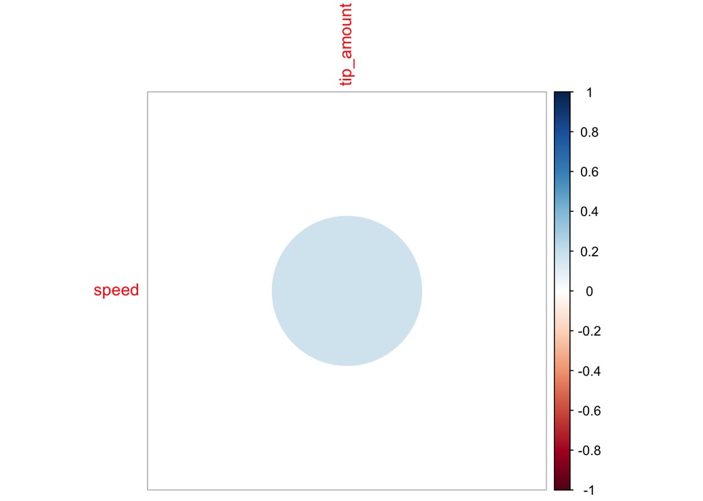

```r
corrplot(cor(tripdat[,c('speed','tip_amount')]),diag=F,type = "upper")
```

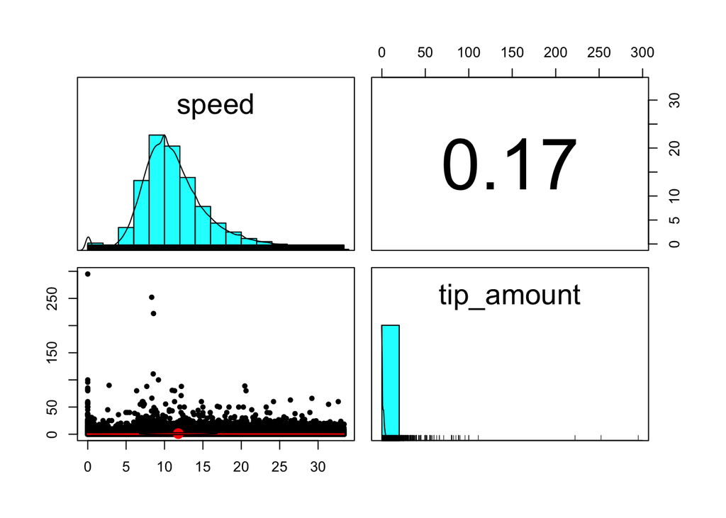

```r
pairs.panels(tripdat[c('speed','tip_amount')])
```

Results of Exploratory Data Analysis:  
- Before doing the analysis, we cleaned the data by removing the NAs and infs (some time gap b/w pickup and drop off were too small which gave us “0”or very small number for time, and led to NA or inf when calculating speed). There are some speed data looks abnormal(e.g.speed:3000mile/hr,dis:34 miles,time:0.1hour), therefore, we removed the outliers of speed(z=3). The correlation b/w speed and tip amount is 0.1730791 which indicates very weak correlation.The correlation matrix gave the correlation very light color which also indicates a very weak correlation. The pair panel shows separated histograms of tip amount and speed(mile/hour), and a line plot of the relationship b/w the two. the graph shows the tips occurs at all speed level, and no association b/w speed and tip amount.

- We have removed missing values and identified outliers, and converted the data type of the columns as necessary.
  - We filtered the dataset to only data within the year of 2018, and removed all negative values from “fare_amount”, “extra”, “mta_tax”, “tip_amount”, “improvement_surcharge”, and “total_amount”.
  - We removed rows in “RatecodeID” that are not within the 1 through 6 range.
  - The remaining outliers are imputed in the data. Although keeping outliers may reduce the statistical significance, they naturally occurred and not caused by statistical errors. Therefore, they were true outliers that may contains important statistical information that worth keeping in the data.

# CRISP-DM: Data Preparation

```r
head(sub_tripdata)
```

```
##   VendorID RatecodeID PULocationID DOLocationID passenger_count trip_distance
## 1        2          1          236          236               5          0.70
## 2        2          1           43           42               5          3.50
## 3        2          1           74          152               1          2.14
## 4        2          1          255          255               1          0.03
## 5        2          1          255          161               1          5.63
## 6        2          1          189           65               5          1.71
##   fare_amount extra mta_tax tolls_amount improvement_surcharge total_amount
## 1         6.0   0.5     0.5            0                   0.3          7.3
## 2        14.5   0.5     0.5            0                   0.3         15.8
## 3        10.0   0.5     0.5            0                   0.3         11.3
## 4         3.0   0.5     0.5            0                   0.3          4.3
## 5        21.0   0.5     0.5            0                   0.3         22.3
## 6         8.5   0.5     0.5            0                   0.3          9.8
##   payment_type trip_type tip_amount
## 1            2         1          0
## 2            2         1          0
## 3            2         1          0
## 4            2         1          0
## 5            2         1          0
## 6            2         1          0
```

Data normalization on the continuous variables/features.

```r
library(caret)
#Encode the data
#Converting categorical variables to factor data type.
#VendorID, RatecodeID, passenger_count, mta_tax, improvement_surcharge, payment_type, trip_type, and extra.
sub_tripdata$VendorID<-as.factor(sub_tripdata$VendorID)
sub_tripdata$RatecodeID<- as.factor(sub_tripdata$RatecodeID)
sub_tripdata$mta_tax<- as.factor(sub_tripdata$mta_tax)
sub_tripdata$improvement_surcharge<- as.factor(sub_tripdata$improvement_surcharge)
sub_tripdata$payment_type<- as.factor(sub_tripdata$payment_type)
sub_tripdata$trip_type<- as.factor(sub_tripdata$trip_type)
sub_tripdata$extra<- as.factor(sub_tripdata$extra)
str(sub_tripdata)
```

```
## 'data.frame':    1045938 obs. of  15 variables:
##  $ VendorID             : Factor w/ 2 levels "1","2": 2 2 2 2 2 2 2 2 2 2 ...
##  $ RatecodeID           : Factor w/ 6 levels "1","2","3","4",..: 1 1 1 1 1 1 1 1 1 1 ...
##  $ PULocationID         : num  236 43 74 255 255 189 189 129 226 145 ...
##  $ DOLocationID         : num  236 42 152 255 161 65 225 82 7 129 ...
##  $ passenger_count      : num  5 5 1 1 1 5 5 1 1 2 ...
##  $ trip_distance        : num  0.7 3.5 2.14 0.03 5.63 1.71 3.45 1.61 1.87 4.12 ...
##  $ fare_amount          : num  6 14.5 10 3 21 8.5 14.5 10 7.5 16.5 ...
##  $ extra                : Factor w/ 5 levels "0","0.2","0.5",..: 3 3 3 3 3 3 3 3 3 3 ...
##  $ mta_tax              : Factor w/ 2 levels "0","0.5": 2 2 2 2 2 2 2 2 2 2 ...
##  $ tolls_amount         : num  0 0 0 0 0 0 0 0 0 0 ...
##  $ improvement_surcharge: Factor w/ 2 levels "0","0.3": 2 2 2 2 2 2 2 2 2 2 ...
##  $ total_amount         : num  7.3 15.8 11.3 4.3 22.3 ...
##  $ payment_type         : Factor w/ 5 levels "1","2","3","4",..: 2 2 2 2 2 2 1 2 2 2 ...
##  $ trip_type            : Factor w/ 2 levels "1","2": 1 1 1 1 1 1 1 1 1 1 ...
##  $ tip_amount           : num  0 0 0 0 0 0 3.16 0 0 0 ...
```

```r
#normalize all continuous independent variables, but will leave Factor variables as is:
norma<-preProcess(sub_tripdata[,1:14], method = c("range") )
normalized_trip<- predict(norma, sub_tripdata[,1:14])
str(normalized_trip)
```

```
## 'data.frame':    1045938 obs. of  14 variables:
##  $ VendorID             : Factor w/ 2 levels "1","2": 2 2 2 2 2 2 2 2 2 2 ...
##  $ RatecodeID           : Factor w/ 6 levels "1","2","3","4",..: 1 1 1 1 1 1 1 1 1 1 ...
##  $ PULocationID         : num  0.89 0.159 0.277 0.962 0.962 ...
##  $ DOLocationID         : num  0.89 0.155 0.572 0.962 0.606 ...
##  $ passenger_count      : num  0.556 0.556 0.111 0.111 0.111 ...
##  $ trip_distance        : num  0.004978 0.02489 0.015218 0.000213 0.040037 ...
##  $ fare_amount          : num  0.006 0.0145 0.01 0.003 0.021 ...
##  $ extra                : Factor w/ 5 levels "0","0.2","0.5",..: 3 3 3 3 3 3 3 3 3 3 ...
##  $ mta_tax              : Factor w/ 2 levels "0","0.5": 2 2 2 2 2 2 2 2 2 2 ...
##  $ tolls_amount         : num  0 0 0 0 0 0 0 0 0 0 ...
##  $ improvement_surcharge: Factor w/ 2 levels "0","0.3": 2 2 2 2 2 2 2 2 2 2 ...
##  $ total_amount         : num  0.0073 0.0158 0.0113 0.0043 0.0223 ...
##  $ payment_type         : Factor w/ 5 levels "1","2","3","4",..: 2 2 2 2 2 2 1 2 2 2 ...
##  $ trip_type            : Factor w/ 2 levels "1","2": 1 1 1 1 1 1 1 1 1 1 ...
```

Encode the data: to determine if there are any categorical variables that need to be encoded and perform the encoding. - Encoding factor variables into numeric using dummy codes.

```r
normalized_trip<- cbind(normalized_trip, tip_amount=sub_tripdata[,15])
#normalized_trip
```

- Factor variables with 2 levels: VendorID, mta_tax, improvement_surcharge, and trip_type.

```r
normalized_trip$mta_tax <- ifelse(normalized_trip$mta_tax == "0.5", 1, 0)

normalized_trip$trip_type<- ifelse(normalized_trip$trip_type=="2", 1, 0)
normalized_trip$improvement_surcharge<- ifelse(normalized_trip$improvement_surcharge=="0.3",1, 0)
normalized_trip$VendorID<- ifelse(normalized_trip$VendorID=="2", 1, 0)
```

- Factor variables with 3 or more levels: RatecodeID, extra, payment_type.

```r
RatecodeID<- as.data.frame(dummy.code(normalized_trip$RatecodeID))
payment_type<- as.data.frame(dummy.code(normalized_trip$payment_type))
extra<- as.data.frame(dummy.code(normalized_trip$extra))
```

- Combine new dummy variables with original data set.

```r
data_reg <- normalized_trip %>%
  cbind( RatecodeID=RatecodeID, payment_type=payment_type, extra=extra) %>%
  select(tip_amount, everything(),-c(RatecodeID, payment_type, extra))

head(data_reg)
```

```
##   tip_amount VendorID PULocationID DOLocationID passenger_count trip_distance
## 1          0        1    0.8901515    0.8901515       0.5555556  0.0049779548
## 2          0        1    0.1590909    0.1553030       0.5555556  0.0248897739
## 3          0        1    0.2765152    0.5719697       0.1111111  0.0152183189
## 4          0        1    0.9621212    0.9621212       0.1111111  0.0002133409
## 5          0        1    0.9621212    0.6060606       0.1111111  0.0400369791
## 6          0        1    0.7121212    0.2424242       0.5555556  0.0121604324
##   fare_amount mta_tax tolls_amount improvement_surcharge total_amount trip_type
## 1 0.006000060       1            0                     1  0.007300073         0
## 2 0.014500145       1            0                     1  0.015800158         0
## 3 0.010000100       1            0                     1  0.011300113         0
## 4 0.003000030       1            0                     1  0.004300043         0
## 5 0.021000210       1            0                     1  0.022300223         0
## 6 0.008500085       1            0                     1  0.009800098         0
##   RatecodeID.1 RatecodeID.5 RatecodeID.2 RatecodeID.4 RatecodeID.3 RatecodeID.6
```

[output cut: 20 more lines]

- The data will be splitted by 80:20 for training and testing, respectively. We choose this ratio because it is the optimal and most commonly used ratio.

```r
library(tidymodels)
#splitting the data in to train and test data set at a ratio of 80:20.
set.seed(7788)
trip_split<-initial_split(data_reg, prop=0.8, strata = tip_amount)

trip_train<-trip_split %>%
  training()

trip_test<-trip_split%>%
  testing()
```

# CRISP-DM: Modeling

• Development of the k-nn regression model. Created a function with the following name and arguments: knn.predict(data_train, data_test, k); -data_train represents the observations in the training set, -data_test represents the observations from the test set, -k is the selected value of k (i.e. the number of neighbors).

• The k-nn algorithm was implemented and used to predict the tip amount for each observation in the test set i.e. data_test.

```r
#knn.predict that returns MSE.
knn.predict<- function(data_train, data_test, k) {
  kmodel<-FNN::knn.reg(train= data_train[,2:28],test= data_test[,2:28], y=data_train[,1], k=k)
  y_pred<- kmodel$pred
  y_test<- data_test[,1]
  mse<- mean((y_test - y_pred)^2)
  return(mse)
}
```

- We tested multiple k values below using our knn.predict function.
- We noticed that as k values increases the MSE tend to increase. For example, when k=20, mse=1.909649. When k=50, mse=2.081655. When k=200, mse= 2.314413. When k=915, mse=2.547468.

```r
knn.predict(trip_train,trip_test,1) #1.762807
```

```
## [1] 1.762807
```

```r
knn.predict(trip_train,trip_test,2) #1.634324
```

```
## [1] 1.634324
```

```r
knn.predict(trip_train,trip_test,3) #1.620225
```

```
## [1] 1.620225
```

```r
knn.predict(trip_train,trip_test,4)  #1.61445
```

```
## [1] 1.61445
```

```r
knn.predict(trip_train,trip_test,5)  #1.642682
```

```
## [1] 1.642682
```

```r
knn.predict(trip_train,trip_test,20)  #1.909649
```

```
## [1] 1.909649
```

```r
#knn.predict(trip_train,trip_test,50)  #2.081655
#knn.predict(trip_train,trip_test,200)  #2.314413
#knn.predict(trip_train,trip_test,915)   #2.547468
```

## CRISP-DM: Evaluation

• The knn.predict function provides the 20 different k-values, th one with the lowest MSE was selected and the MSE was visualized subsequently.

- We used two method to test 20 different k-values: for loop and sapply(), which yield the same results.

```r
#using loop
mse_value<-c()
for (k in 1:20){
  kmse<-knn.predict(trip_train,trip_test,k)
  mse_value<- c(mse_value,kmse)
}
mse_value
```

```
##  [1] 1.762807 1.634324 1.620225 1.614450 1.642682 1.674952 1.701861 1.729461
##  [9] 1.753900 1.773183 1.794606 1.812235 1.830116 1.842718 1.855121 1.866550
## [17] 1.880715 1.889765 1.899109 1.909649
```

```r
# define 20 different values of k to evaluate using sapply
k = c(1:20)

#using sapply
knn_MSE=sapply(k,knn.predict,data_train=trip_train,data_test=trip_test)
knn_MSE
```

```
##  [1] 1.762807 1.634324 1.620225 1.614450 1.642682 1.674952 1.701861 1.729461
##  [9] 1.753900 1.773183 1.794606 1.812235 1.830116 1.842718 1.855121 1.866550
## [17] 1.880715 1.889765 1.899109 1.909649
```

- “knn_result” data frame below displays the k values and associated MSE from lowest to highest.

```r
#knn_results
knn_result<-data.frame(k,MSE=knn_MSE)
knn_result<-knn_result%>%
  arrange(MSE)
knn_result
```

```
##     k      MSE
## 1   4 1.614450
## 2   3 1.620225
## 3   2 1.634324
## 4   5 1.642682
## 5   6 1.674952
## 6   7 1.701861
## 7   8 1.729461
## 8   9 1.753900
## 9   1 1.762807
## 10 10 1.773183
## 11 11 1.794606
## 12 12 1.812235
## 13 13 1.830116
## 14 14 1.842718
## 15 15 1.855121
## 16 16 1.866550
## 17 17 1.880715
## 18 18 1.889765
## 19 19 1.899109
## 20 20 1.909649
```

```r
#best K
best_k=k[which.min(knn_MSE)]
best_k
```

```
## [1] 4
```

• Visualization of MSE: - The line chart below shows the MSE of each k value from 1 to 20. We can see that MSE is lowest when k=4.

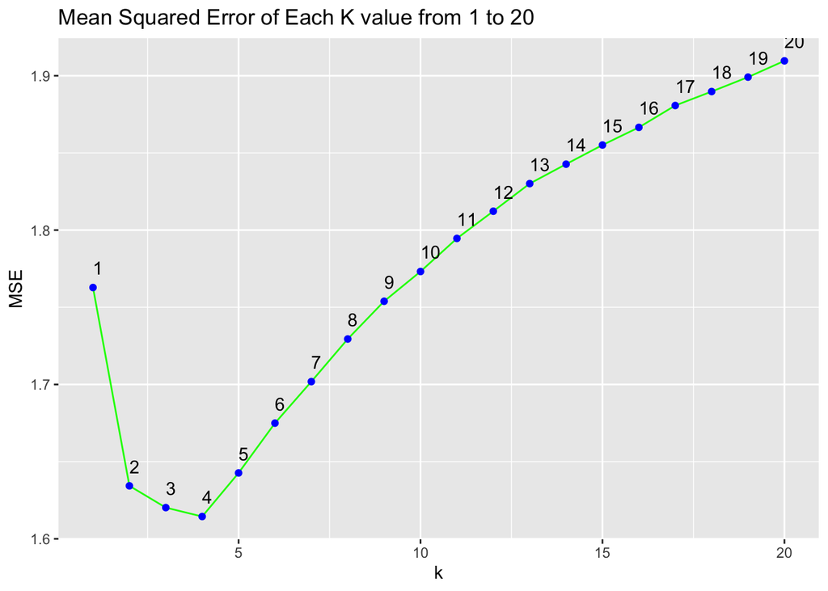

```r
ggplot(knn_result,aes(x=k,y=MSE,label=k)) +
geom_line(color = "green") + geom_point(color = "blue") + geom_text(hjust=0, vjust=-1)+
  ggtitle("Mean Squared Error of Each K value from 1 to 20")
```

```r
# obtaining an error in the first chunk regarding tip amount data frame.
#Creating separate dataframe for 'Tip amount' feature which is our target.

train_tip_amount <-trip_train[,1]
test_tip_amount <- trip_test[,1]
```

```r
#model accuracy when k=4
k1 <- FNN::knn.reg(train= trip_train[,2:28],test= trip_test[,2:28], y=train_tip_amount, k=4)
accuracy <- 100 * sum(test_tip_amount == k1$pred)/NROW(test_tip_amount)
accuracy
```

```
## [1] 55.22831
```

```r
k20 <- FNN::knn.reg(train= trip_train[,2:28],test= trip_test[,2:28], y=train_tip_amount, k=20)
k20_accuracy <- 100 * sum(test_tip_amount == k20$pred)/NROW(test_tip_amount)
k20_accuracy
```

```
## [1] 47.32059
```

- The model accuracy is about 55% when k is 4.

-Changing the split to check 70:30 to check for better accuracy.

```r
# train and test data set split at a ratio of 70:30.
set.seed(1357)

trip_split1<-initial_split(data_reg, prop=0.7, strata = tip_amount)

trip_train1<-trip_split1 %>%
  training()

trip_test1<-trip_split1%>%
  testing()
```

```r
#Creating separate dataframe for 'Tip amount' feature which is our target.
train_tip_amount <-trip_train1[,1]
test_tip_amount <- trip_test1[,1]
```

```r
#Checking for MSE for k values 1:20
k<- c(1:20)
kdf_one <- data.frame(k)
kdf_one$mse <- 0

for (i in 1:nrow(kdf_one)){
k <- kdf_one$k[i]
kdf_one$mse[i] <- knn.predict(trip_train1,trip_test1,k)
}

kdf_one
```

```
##     k      mse
## 1   1 1.679089
## 2   2 1.519029
## 3   3 1.492576
## 4   4 1.498595
## 5   5 1.508292
## 6   6 1.518362
## 7   7 1.532187
## 8   8 1.548050
## 9   9 1.559702
## 10 10 1.576239
## 11 11 1.588947
## 12 12 1.601605
## 13 13 1.613466
## 14 14 1.624190
## 15 15 1.636210
## 16 16 1.646103
## 17 17 1.655945
## 18 18 1.665873
## 19 19 1.675472
## 20 20 1.682746
```

```r
#best k
kdf_one$k[which.min(kdf_one$mse)]
```

```
## [1] 3
```

- Best k is 3.

```r
#build knn regression model using best k (3).
k1_test <-  FNN::knn.reg(train= trip_train1[,2:28],test= trip_test1[,2:28], y=train_tip_amount, k=3)

#Checking for accuracy
accuracy_test <- 100 * sum(test_tip_amount == k1_test$pred)/NROW(test_tip_amount)
accuracy_test
```

```
## [1] 57.23573
```

- The accuracy of a 70:30 split model is 57.24%, when k is 3.

```r
#joining MSE from both 70:30 and 80:20 split data by the k value.
kdf_one<-kdf_one%>%
full_join(knn_result) %>%
  rename("mse_values_70" = "mse","mse_values_80" = "MSE")
kdf_one
```

```
##     k mse_values_70 mse_values_80
## 1   1      1.679089      1.762807
## 2   2      1.519029      1.634324
## 3   3      1.492576      1.620225
## 4   4      1.498595      1.614450
## 5   5      1.508292      1.642682
## 6   6      1.518362      1.674952
## 7   7      1.532187      1.701861
## 8   8      1.548050      1.729461
## 9   9      1.559702      1.753900
## 10 10      1.576239      1.773183
## 11 11      1.588947      1.794606
## 12 12      1.601605      1.812235
## 13 13      1.613466      1.830116
## 14 14      1.624190      1.842718
## 15 15      1.636210      1.855121
## 16 16      1.646103      1.866550
## 17 17      1.655945      1.880715
## 18 18      1.665873      1.889765
## 19 19      1.675472      1.899109
## 20 20      1.682746      1.909649
```

This plot below shows the relationship between k value and mse in both 80:20 split data and 70:30 split data.

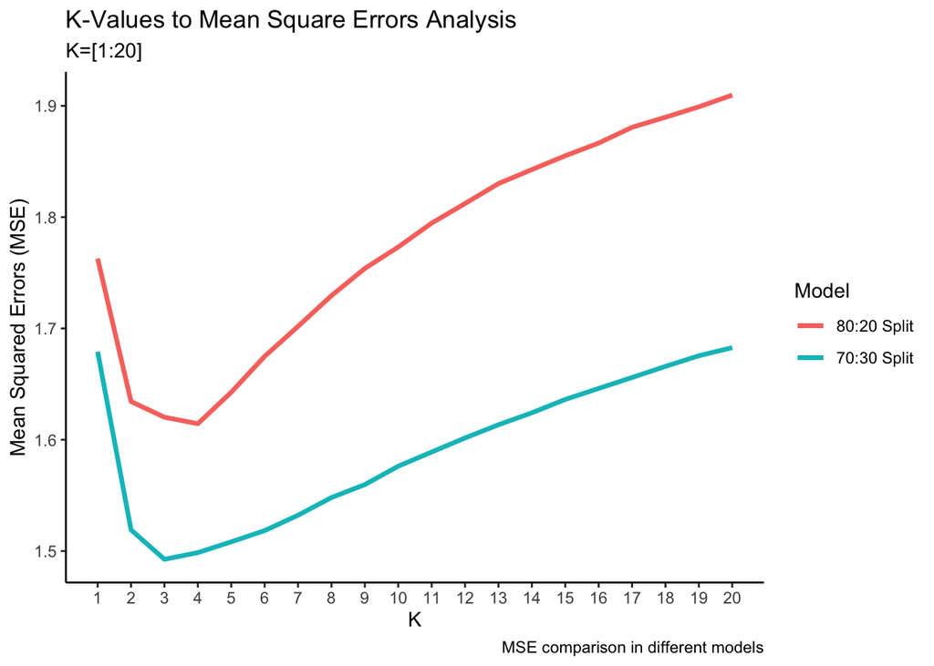

```r
ggplot(kdf_one, aes(x = k)) + geom_line(aes(y = mse_values_70, color = "lightblue"),size = 1.2) + geom_line(aes(y = mse_values_80, colour = "green"), size = 1.2) + theme_classic() + labs(title = "K-Values to Mean Square Errors Analysis", x = "K", y = "Mean Squared Errors (MSE)", caption = "MSE comparison in different models", subtitle = "K=[1:20]")+scale_x_continuous(breaks = seq(0,20,1))+scale_color_discrete(name = "Model", labels=c("80:20 Split","70:30 Split"))
```

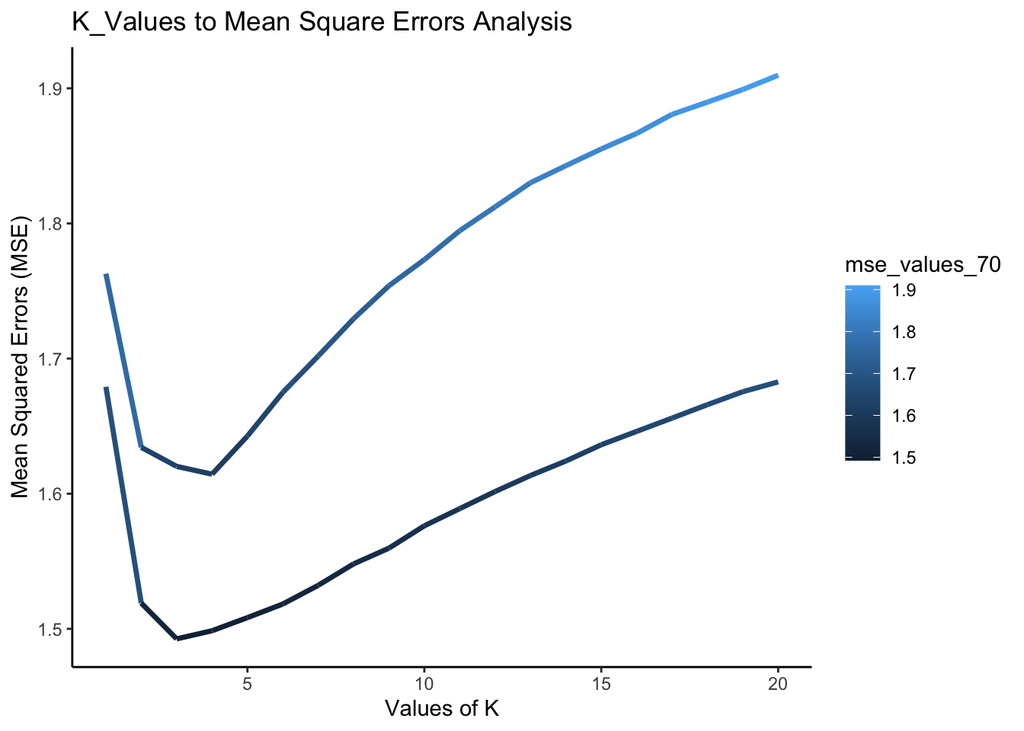

```r
plot <- ggplot(kdf_one, aes(x = k)) + geom_line(aes(y = mse_values_70, colour = mse_values_70),size = 1.2) + geom_line(aes(y = mse_values_80, colour = mse_values_80), size = 1.2) + theme_classic() + labs(title = "K_Values to Mean Square Errors Analysis", x = "Values of K", y = "Mean Squared Errors (MSE)" )

plot
```

Conclusion: Our initial model which split the data in 80:20 has a best k value of 4 and an accuracy of 55%. Our second set of model which split the data in 70:30 has a best k value of 3 and an accuracy of 57%. -By changing the split percentage from 80:20 to 70:30, the prediction accuracy increased by 2%.